# Introduction to DATA607 CUNY SPS

[figure not shown]

## R Markdown from R Studio - Intro

R Markdown provides an authoring framework for data science. You can use a single R Markdown file to both

### Installation

Like the rest of R, R Markdown is free and open source. You can install the R Markdown package from CRAN with:

```
install.packages("rmarkdown")
```

[R Markdown Cheatsheet](https://www.rstudio.com/wp-content/uploads/2016/03/rmarkdown-cheatsheet-2.0.pdf) [R Markdown Reference Guide](https://www.rstudio.com/wp-content/uploads/2015/03/rmarkdown-reference.pdf)

## Viridis colors

Code below demonstrates to color palettes in the viridis package. Each plot displays a contour map of the Maunga Whau volcano in Auckland, New Zealand.

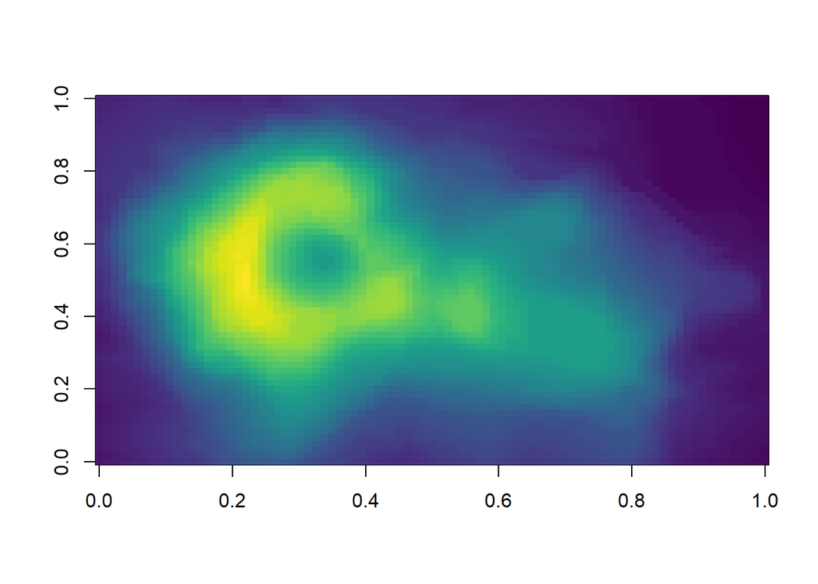

### Magma colors

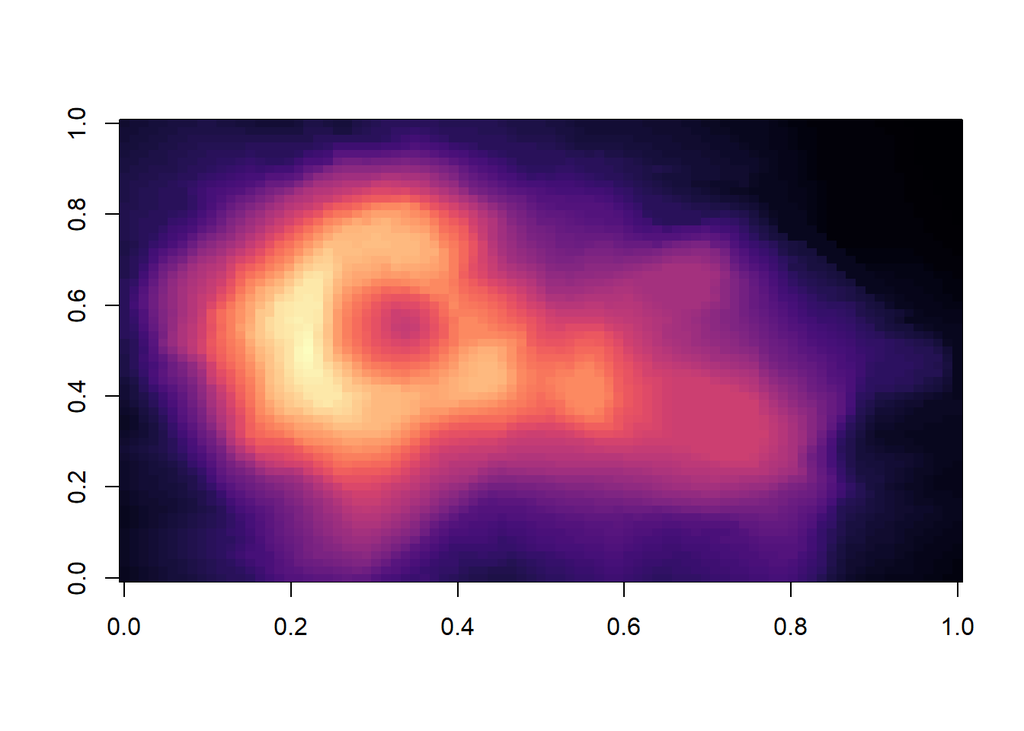

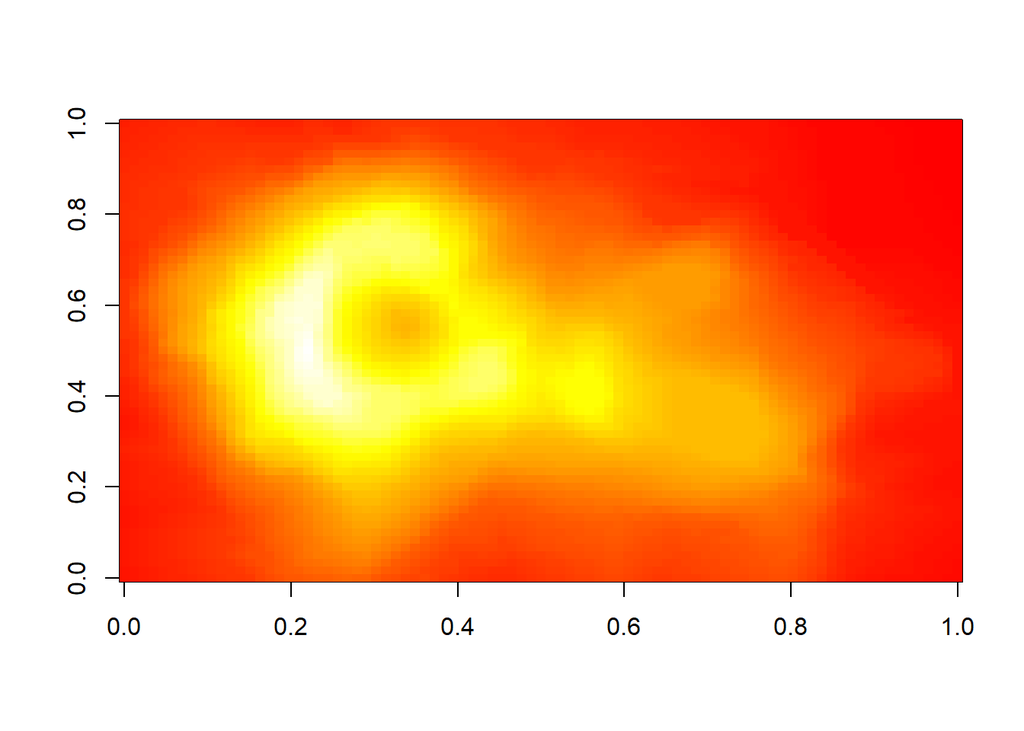

Heat color example

```r
colorFunc <- "heat.colors"
# colorFunc <- "terrain.colors"
# colorFunc <- "topo.colors"
# colorFunc <- "cm.colors"
# colorFunc <- "rainbow"
```

## Simple Demo languages

### Bash

```
ls *.Rmd
```

### Python

```python
x = 'hello, python world!'
print(x.split(' '))
```

[marmap](https://cran.r-project.org/web/packages/marmap/index.h)

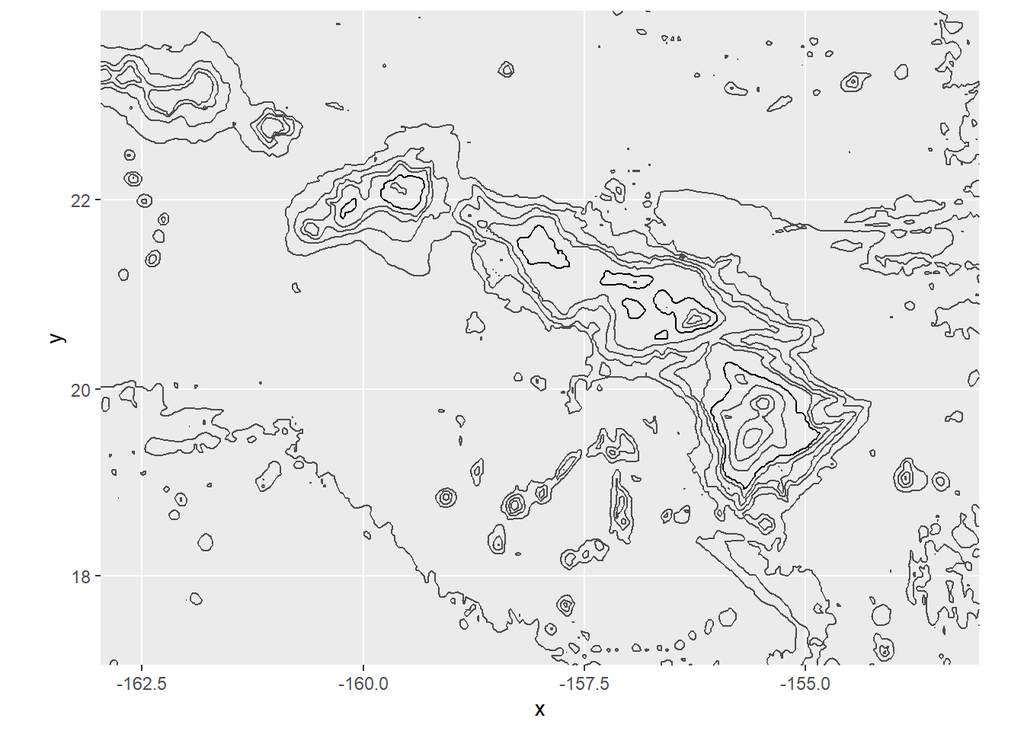

```r
data(list = params$data)
autoplot(get(params$data))
```

### Tables

Below packages are for tables

- [xtable](https://cran.r-project.org/web/packages/xtable/)
- [stargazer](https://cran.r-project.org/web/packages/stargazer/)
- [pander](http://rapporter.github.io/pander/)
- [tables](https://cran.r-project.org/web/packages/tables/)
- [ascii](http://eusebe.github.io/ascii/)
- etc.

It is also very easy to make tables with knitr’s `kable` function:

**Note the use of the results=‘asis’ chunk option. This is required to ensure that the raw table output isn’t processed further by knitr.**

A knitr kable.

|  | mpg | cyl | disp | hp | drat | wt | qsec | vs | am | gear | carb |
| --- | --- | --- | --- | --- | --- | --- | --- | --- | --- | --- | --- |
| Mazda RX4 | 21.0 | 6 | 160 | 110 | 3.90 | 2.620 | 16.46 | 0 | 1 | 4 | 4 |
| Mazda RX4 Wag | 21.0 | 6 | 160 | 110 | 3.90 | 2.875 | 17.02 | 0 | 1 | 4 | 4 |
| Datsun 710 | 22.8 | 4 | 108 | 93 | 3.85 | 2.320 | 18.61 | 1 | 1 | 4 | 1 |
| Hornet 4 Drive | 21.4 | 6 | 258 | 110 | 3.08 | 3.215 | 19.44 | 1 | 0 | 3 | 1 |
| Hornet Sportabout | 18.7 | 8 | 360 | 175 | 3.15 | 3.440 | 17.02 | 0 | 0 | 3 | 2 |

### Markdown Basics

You can use Pandoc’s Markdown to make:

# A level-one header

# Headers

## A level-two header

## ATX-style level-two header

### ATX-style level-three header

# A level-one header with a link and *emphasis*

I like several of their flavors of ice cream: #22, for example, and #5.

## Header Attributes

# Level-one header

## My header

## My other header

# Level-one unnumbered header

# Level-one unnumbered header

*Dogs*?–in *my* house?

# Lists

## Bullet Lists

- one
- two
- three
- one
- two
- three
- here is my first list item.
- and my second.
- here is my first list item.
- and my second.

### The four-space rule

- First paragraph.

  Continued.
- Second paragraph. With a code block, which must be indented eight spaces:

  { code }
- fruits
  - apples
    - macintosh
    - red delicious
  - pears
  - peaches
- vegetables
  - broccoli
  - chard
- A lazy, lazy, list item.
- Another one; this looks bad but is legal.

  Second paragraph of second list item.

## Ordered Lists

1. one
2. two
3. three

and this one:

5. one
6. two
7. three

### fancy_lists

1. one
2. two

### Extension: startnum

9. Ninth
10. Tenth
11. Eleventh
    1. subone
    2. subtwo
    3. subthree
2. Two
3. Three
1. Four
- Five

### Default Marker

1. one
2. two
3. three

### Term 1

: Definition 1

Definition 2

```
{ some code, part of Definition 2 }
```

Third paragraph of definition 2.

# Links

## Automatic Links

http://google.com sam@green.eggs.ham

## Inline links

This is an inline link, and here’s [one with a title](http://fsf.org).

## Emails need the prefix mailto

Write me!

## Reference Links

Test label 1

Test label 2

[Test label 3](http://fsf.org)

**With angle brackets**

**With title**

**Using link labels**

Here is my link

## Internal link

See the Introduction.

- Block quotes
- Latex Equations
- Horizontal rules
- Tables
- Footnotes
- Bibliographies and Citations
- Slide breaks
- Italicized text
- Bold text
- Superscripts
- Subscripts
- Strikethrough text